# Project 2 - Edson

Published

April 6, 2025

## Our Team

Fill the vector `our_team` with the full names (First Last) of each team member. Although this task is worth no points, failing to complete this task will result in a one-point deduction.

```r
our_team = c('Arnold Jiang', 'John Woo', 'Tong Dai', 'Willow Yang')
our_team
```

```
[1] "Arnold Jiang" "John Woo"     "Tong Dai"     "Willow Yang"
```

## Our Country

Fill the string `our_country` with the country of the football team you wish to follow during the World Cup. Only one country must be selected. The name of this country must be spelled exactly as it appears in the `wc_sched` dataset (linked below). Hence you must select one of the countries from this dataset. Although this task is worth no points, failing to complete this task will result in a three-point deduction.

```r
our_country = 'Argentina'
```

## Our Seed

Fill the value `our_seed` with a calculated seed to precede all random sampling actions throughout this project. This way, your code can be executed for verification and reproduction. Although this task is worth no points, failing to complete this task will result in a five-point deduction.

```r
# calculate the seed to be the sum of the PUIDs of each teammate and then the remainder after dividing by 1746.
# for example, if you have two teammates with PUIDs 888888888 & 999999999,
our_seed = sum(920327399, 920400588, 920251660, 920293028) %% 1746
```

## Introduction

The [FIFA World Cup](https://en.wikipedia.org/wiki/FIFA_World_Cup) is a quadrennial football (soccer in the US) tournament that captures the world’s attention like no other sporting event. At its conclusion, one country will stand as the sole victor. Argentina is the reigning champion, having won the title in 2022.

Arguably, there is no greater single competitor in the history of this event than **Edson Arantes do Nascimento**, better known by his nickname **Pelé**. He led the Brazilian national team to three World Cup titles during his career.

For the 2026 World Cup, the matches will be held in three countries - USA, Canada, and Mexico. For the first time ever, 48 countries will qualify for this tournament. They will be segmented into 12 different groups of four countries each. Each country will play three matches against the three other countries in their group. Based on their performance in the group stage, they may qualify for one of 32 spots in the knockout stage. There, it will become a single-elimination tournament (one loss and it’s over) until one country remains victorious.

In this project, we will focus on answering questions related to the World Cup and the sport of football. Computational models and automated processes will be created from data related to the following three topics:

1. Travel Planning
2. Goal Modeling
3. Match Predicting

At the conclusion of each section, a written summary (5-10 sentences) of your work is required. The summaries should include:

- commentary on the results of your output
- potential enhancements to the models/processes
- any answers to questions from prior tasks within the section

The project will be graded on a basis of 100 maximum points.

There is an optional fourth section that can earn you bonus points (up to 33) for modeling the knockout stage of the 2026 World Cup. You can earn more than 100 points on this project with the completion of this section.

## The Necessary Packages

Run this entire code chunk BEFORE proceeding to ensure that all subsequent code are recognized and executable.

```r
library(tidyverse)
library(highcharter)
library(leaflet)
library(gt)
library(corrplot)
```

## A. Travel Planning [*33 pts total*]

As the world descends to North America for the 2026 World Cup, it will be a challenge to coordinate the travel plans for the myriad visitors. This section will focus on creating automated processes to organize the traveling activity of potential visitors.

#### A0a. Data

In order to simplify the logistics of this section, several datasets will be utilized:

- `wc_sched`: the schedule of the World Cup 2026 group stage matches (while the dates and locations of the matches are set in stone, the actual participants have been simulated so that we can all use the same starting data)
- `wc_airports`: a selected list of the airports near the match venues
- `wc_flights`: a full weekly cycle of flights to and from the selected airports
- `wc_golf`: a sample of golf courses in North America

1. Data Dictionary - `wc_sched`

- match: the number representing the sequence in which the matches will be played
- group: the group (A to L) to which the match participants belong
- match_dt: the date on which the match is scheduled to be played
- ctry_a: the first of the two participants on the match
- ctry_b: the second of the two participants on the match
- venue: the name of the venue where the match will be played
- city: the city where the venue is located
- lat: the latitude of a spot on the venue field
- lng: the longitude of a spot on the venue field

2. Data Dictionary - `wc_airports`

- name: the full name of the airport
- code: a unique 3-letter code of the airport
- lat: the latitude of a spot on the airport
- lng: the longitude of a spot on the airport

3. Data Dictionary - `wc_flights`

- dow: the day of week on which the flight departs
- dep: the time (hhmm), in the time zone of the departing airport, at which the flight is scheduled to depart
- arr: the time (hhmm), in the time zone of the arriving airport, at which the flight is scheduled to arrive
- airline: a unique 2-letter code of the airline running the flight
- orig: the airport code of the originating airport
- dest: the airport code of the destination airport

4. Data Dictionary - `wc_golf`

- course: the name of the golf course
- country: the country where the course is located
- lat: the latitude of a spot on the golf course
- lng: the longitude of a spot on the golf course

#### A0b. Distance Function

This function will calculate the spherical distance (in miles) between two sets of geo-coordinates using the [Haversine formula](https://en.wikipedia.org/wiki/Haversine_formula). Run this code chunk so that you can utilize it as needed for this project.

```r
# the distance function to calculate the distance in miles between two sets of geo-coordinates (lat1, lng1) & (lat2, lng2)
dist_mi = function(lat1, lng1, lat2, lng2) {
  R = 3963 # radius of earth in miles
  r1 = lat1 * pi / 180
  r2 = lat2 * pi / 180
  d1 = (lat2 - lat1) * pi / 180
  d2 = (lng2 - lng1) * pi / 180
  a = sin(d1/2)^2 + cos(r1) * cos(r2) * sin(d2/2)^2
  return(2 * R * atan2(sqrt(a), sqrt(1-a)))
}
```

#### A1. Getting Around [*14 pts*]

As your team members are avid fans of the sport and the magnitude of this global event, you are asked to create a function `itinerary` that will take as input three parameters:

1. `ctry`: a country name (text string) for the country you wish to follow during the group stage
2. `pdt`: a two-element vector containing the preferred 8-hour segment (integer: 1 to 3) referring to which third of the day the traveler wishes to depart (1: 0 to 759, 2: 800 to 1559, 3: 1600 to 2359) for just the initial leg of each flight
3. `conn`: a two-element vector containing the number of flight connections (integer: 0 to 2) for each flight (n.b. a non-stop flight has zero connections)

The function must return a travel itinerary (as a data frame) that will contain, for each leg of the flight trip, the following columns:

- flt: the flight number (12 or 23; 12 goes from match 1 to match 2, 23 goes from match 2 to match 3)
- leg: the leg of the flight (1 to 3)
- dep: the departure airport code
- arr: the arrival airport code
- dod: the date of departure
- tod: the time of departure
- doa: the date of arrival
- toa: the time of arrival
- the distance between (use `dist_mi` function) the two airports

This function must be able to return qualifying flights for up to two connections between the cities of travel.

The flight details must be optimized for:

- dates (at least one day before a match)
- airports (nearest airport to the match venue)
- time between legs of connecting flights (at least an hour)
- total flight distance (minimize for connecting flight trips)

Assume that you are already at the location of the first group stage match of your country.

```r
# returns nearest airport given lat and lng coords
findNearestAirport = function(given_lat, given_lng) {
  nearest_airport <- wc_airports |>
    mutate(dist = dist_mi(given_lat, given_lng, lat, lng)) |>
    arrange(dist) |>
    slice(1) |>
    select(code, lat, lng)
  return(nearest_airport)
}

getTimeRanges <- function(pdt) {
  if (pdt == 1) {
      return(c(0, 759))
    } else if (pdt == 2) {
      return(c(800, 1559))
    } else {
      return(c(1600, 2359))
    }
}

getAirportLatLng <- function(airport) {
  if (airport == "LGA") {
    df <- data.frame(lat = 40.7766, lng = -73.8742)
    return(df) #LGA flights are not in dataset, but there are LGA flights
  }
  latLng <- wc_airports |>
    filter(code == airport) |>
    select(lat, lng)
  return(latLng)
}


formatTime <- function(time) {
  time_str <- sprintf("%04d", time)
  res <- paste0(substr(time_str, 1, 2), ":", substr(time_str, 3, 4), ":00")
  return(res)
}

formatTime2 <- function(time) {
  time_str <- sprintf("%04d", time)
  res <- paste0(substr(time_str, 1, 2), ":", substr(time_str, 3, 4))
  return(res)
}

findDirectFlights = function(dep_airport, arr_airport, match_dow, prev_dt, match_dt, pdt) {
  # get time ranges based on pdt, lat and long of depature and arrival airports
  time_ranges <- getTimeRanges(pdt)
  depLatLng <- getAirportLatLng(dep_airport)
  arrLatLng <- getAirportLatLng(arr_airport)

  directFlightOptions <- wc_flights |>
    filter(orig == dep_airport) |>   # flights departing from dep_airport
    filter(dest == arr_airport) |>   # flights arriving at arr_airport
    filter(
      # make sure the flight options are within the preferred time range for departure
      (dep >= time_ranges[1] & dep <= time_ranges[2])
    ) |>
    # represent day of week of flights numerically
    mutate(dow = match(dow, c("SUN", "MON", "TUE", "WED", "THU", "FRI", "SAT"))) |>
    # get departure date for flight
    mutate(dep_date =
             ifelse(dow < match_dow, as.Date(match_dt) - days(match_dow - dow),
                    as.Date(match_dt) - days(match_dow - dow + 7)),
           dep_date = as.Date(dep_date)
           )|>
    # if it's a red eye flight, arr date becomes the next day
    mutate(
      arr_date = ifelse(arr < dep, as.Date(dep_date) + days(1), as.Date(dep_date)),
      arr_date = as.Date(arr_date)
    ) |>
    # make sure that flight is departing only after we're there at location
    filter(dep_date > as.Date(prev_dt)) |>
    # make sure flight is arriving a day before match_dt
    filter(arr_date < as.Date(match_dt)) |>
    # get dist between airports
    mutate(dist = dist_mi(depLatLng$lat, depLatLng$lng, arrLatLng$lat, arrLatLng$lng)) |>
    # arrange by the total dist and then the latest arrival date
    arrange(dist, desc(arr_date))
  return(directFlightOptions)
}

findOneConnection = function(dep_airport, arr_airport, match_dow, prev_dt, match_dt, pdt) {
  # get time ranges based on pdt, lat and long of depature and arrival airports
  time_ranges <- getTimeRanges(pdt)
  depLatLng <- getAirportLatLng(dep_airport)
  arrLatLng <- getAirportLatLng(arr_airport)

   # --- find qualifying first legs ---
  qualifyingFirstLeg <- wc_flights |>
    rowwise() |>
    filter(orig == dep_airport) |>   # flights departing from dep_airport
    filter(dest != arr_airport) |>   # first leg of the flight should not arrive at arr_airport
    filter(
      # make sure the flight options are within the preferred time range for departure
      (dep >= time_ranges[1] & dep <= time_ranges[2])
    ) |>
    # represent day of week of flights numerically
    mutate(dow = match(dow, c("SUN", "MON", "TUE", "WED", "THU", "FRI", "SAT"))) |>
    # get dist between airports
    mutate(dist = dist_mi(depLatLng$lat, depLatLng$lng, getAirportLatLng(dest)$lat, getAirportLatLng(dest)$lng)) |>
    # selected wanted columns
    select(dow, dep, arr, orig, dest, dist)

   # --- find possible second legs ---
  possibleSecondLeg <- wc_flights |>
    rowwise() |>
    filter(orig %in% qualifyingFirstLeg$dest) |>   # orig needs to be a dest of the first leg
    filter(dest == arr_airport) |>                 # flight goes to final dest (arr_airport)
    # get dist between airports
    mutate(dist = dist_mi(getAirportLatLng(orig)$lat, getAirportLatLng(orig)$lng, arrLatLng$lat, arrLatLng$lng)) |>
    # represent day of week of flights numerically
    mutate(dow = match(dow, c("SUN", "MON", "TUE", "WED", "THU", "FRI", "SAT")))

   # --- find qualifying flights with one connection ---
  qualifyingConnections <- qualifyingFirstLeg |>
    # merge the first and second legs to form one connection
    left_join(possibleSecondLeg, by = c('dest' = 'orig'), relationship = "many-to-many") |>
    # get departure and arrival dates
    mutate(
      final_dep_date = ifelse(dow.y < match_dow,
                              as.Date(match_dt) - days(match_dow - dow.y),
                              as.Date(match_dt) - days(match_dow - dow.y + 7)),
      final_dep_date = as.Date(final_dep_date),
      final_arr_date = ifelse(arr.y > dep.y,
                                     final_dep_date, final_dep_date + days(1)),
      final_arr_date = as.Date(final_arr_date),
      first_dep_date = ifelse(dow.x == dow.y, as.Date(final_dep_date),
                              ifelse(dow.y > dow.x,
                                     as.Date(final_dep_date) - days(dow.y - dow.x),
                                     as.Date(final_dep_date) - days(dow.y - dow.x + 7))),
      first_dep_date = as.Date(first_dep_date),
      first_arr_date = ifelse(arr.x > dep.x, first_dep_date, first_dep_date + days(1)),
      first_arr_date = as.Date(first_arr_date)
    ) |>
    # make sure that flight is departing only after we're there at location
    filter(first_dep_date > as.Date(prev_dt)) |>
    # make sure that flight is arriving a day before match_dt
    filter(final_arr_date < as.Date(match_dt)) |>
    # calculate layover duration of flights
    mutate(layover_duration = ifelse(final_arr_date == first_dep_date,
                                            hm(dep.y) - hm(arr.x),
                                     difftime(as.POSIXct(paste(final_arr_date,
                                                         formatTime(dep.y)), tz="UTC"),
                                              as.POSIXct(paste(first_dep_date,
                                                         formatTime(arr.x)), tz="UTC"),
                                              units = "mins"))) |>
    # make sure that we have at least an hour in between layover
    filter(layover_duration >= 60) |>
    mutate(total_dist = dist.x + dist.y) |>
    select(
      first_dow = dow.x,
      first_dep = dep.x,
      first_arr = arr.x,
      first_orig = orig,
      first_dest = dest,
      second_dow = dow.y,
      second_dep = dep.y,
      second_arr = arr.y,
      second_dest = dest.y,
      first_dep_date,
      first_arr_date,
      final_dep_date,
      final_arr_date,
      first_dist = dist.x,
      second_dist = dist.y,
      total_dist,
      layover_duration
    ) |>
    # arrange by the shortest layover duration
    arrange(layover_duration) |>
    # remove dupes that fly to the same airports and choose only the one w shortest layover
    group_by(first_orig, first_dest, second_dest) |>
    slice(1) |>
    ungroup() |>
    # arrange by total dist and the latest final arrival date
    arrange(total_dist, desc(final_arr_date))
  return(qualifyingConnections)
}
```

```r
findTwoConnection = function(dep_airport, arr_airport, match_dow, prev_dt, match_dt, pdt) {
  # get time ranges based on pdt, lat and long of depature and arrival airports
  time_ranges <- getTimeRanges(pdt)
  depLatLng <- getAirportLatLng(dep_airport)
  arrLatLng <- getAirportLatLng(arr_airport)

  # --- find qualifying first leg ---
  qualifyingFirstLeg <- wc_flights |>
    filter(orig == dep_airport, # flights departing from dep_airport
           dest != arr_airport, # first leg of the flight should not arrive at arr_airport
           # make sure the flight options are within the preferred time range for departure
           (dep >= time_ranges[1] & dep <= time_ranges[2])
           )

  # --- find qualifying second leg ---
  possibleSecondLeg <- wc_flights |>
    filter(orig %in% qualifyingFirstLeg$dest,
           dest != arr_airport & dest != dep_airport)

  # --- find qualifying third leg ---
  possibleThirdLeg <- wc_flights |>
    filter(orig %in% possibleSecondLeg$dest,
           dest == arr_airport)

  # --- find qualifying last connection ---
  possibleLastConn <- possibleSecondLeg |>
    # merge second leg and third leg together
    left_join(possibleThirdLeg, by = c('dest' = 'orig'), relationship = "many-to-many") |>
    # get the depature and arrival dates for the flights
    mutate(dow.x = match(dow.x, c("SUN", "MON", "TUE", "WED", "THU", "FRI", "SAT")),
           dow.y = match(dow.y, c("SUN", "MON", "TUE", "WED", "THU", "FRI", "SAT")),
           final_dep_date = ifelse(dow.y < match_dow,
                                   as.Date(match_dt) - days(match_dow - dow.y),
                            as.Date(match_dt) - days(match_dow - dow.y + 7)),
           final_dep_date = as.Date(final_dep_date),
           final_arr_date = ifelse(arr.y > dep.y,
                                     final_dep_date, final_dep_date + days(1)),
           final_arr_date = as.Date(final_arr_date),

           second_dep_date = ifelse(dow.x == dow.y, as.Date(final_dep_date),
                                      ifelse(dow.y > dow.x,
                                             as.Date(final_dep_date) - days(dow.y - dow.x),
                                      as.Date(final_dep_date) - days(dow.y - dow.x + 7))),
           second_dep_date = as.Date(second_dep_date),
           second_arr_date = ifelse(arr.x > dep.x, second_dep_date, second_dep_date + days(1)),
           second_arr_date = as.Date(second_arr_date)
           ) |>
    # make sure that final arrival date arrives before match dt
    filter(final_arr_date < as.Date(match_dt)) |>
    # get second layover duration date
    mutate(second_layover_duration = ifelse(final_arr_date == second_dep_date,
                                            hm(dep.y) - hm(arr.x),
                                     difftime(as.POSIXct(paste(final_arr_date,
                                                         formatTime(dep.y)), tz="UTC"),
                                              as.POSIXct(paste(second_dep_date,
                                                         formatTime(arr.x)), tz="UTC"),
                                              units = "mins"))) |>
    # make sure the second layover duration is at least an hr
    filter(second_layover_duration >= 60)

  qualifyingConns <- qualifyingFirstLeg |>
    # merge possible first leg and last connections
    inner_join(possibleLastConn, by = c("dest" = "orig"), relationship = "many-to-many") |>
    select(first_dow = dow,
           first_dep = dep,
           first_arr = arr,
           first_orig = orig,
           first_dest = dest,
           second_dow = dow.x,
           second_dep = dep.x,
           second_arr = arr.x,
           second_dest = dest.y,
           third_dow = dow.y,
           third_dep = dep.y,
           third_arr = arr.y,
           third_dest = dest.y.y,
           second_dep_date,
           second_arr_date,
           final_dep_date,
           final_arr_date,
           second_layover_duration
           ) |>
    # get departure and arrival dates for the first leg
    mutate(first_dow = match(first_dow, c("SUN", "MON", "TUE", "WED", "THU", "FRI", "SAT")),
           first_dep_date = ifelse(first_dow == second_dow, as.Date(second_dep_date),
                             ifelse(second_dow > first_dow,
                                    as.Date(second_dep_date) - days(second_dow - first_dow),
                                    as.Date(second_dep_date) - days(second_dow - first_dow + 7))),
           first_dep_date = as.Date(first_dep_date),
           first_arr_date = ifelse(first_arr > first_dep, first_dep_date,
                                   first_dep_date + days(1)),
           first_arr_date = as.Date(first_arr_date)
           ) |>
    mutate(first_layover_duration = ifelse(first_arr_date == second_dep_date,
                                           hm(second_dep) - hm(first_arr),
                                     difftime(as.POSIXct(paste(second_dep_date,
                                                         formatTime(second_dep)), tz="UTC"),
                                              as.POSIXct(paste(first_arr_date,
                                                         formatTime(first_arr)), tz="UTC"),
                                              units = "mins")),
           total_layover_duration = second_layover_duration + first_layover_duration) |>
    # make sure that first layover is at least an hr
    filter(first_layover_duration >= 60) |>
    # make sure that flight is departing only after we're there at location
    filter(first_dep_date > as.Date(prev_dt)) |>
    # arrange by shortest total layover duration
    arrange(total_layover_duration) |>
    # remove dupes that fly to same airport (only the one with shortest total layover stays)
    group_by(first_orig, first_dest, second_dest, third_dest) |>
    slice(1) |>
    ungroup() |>
    # arrange by the latest final arrival date
    arrange(desc(final_arr_date))

  qualifyingConns <- qualifyingConns |>
    rowwise() |>
    # get distances between airports
    mutate(first_dist = dist_mi(getAirportLatLng(first_orig)$lat,
                                getAirportLatLng(first_orig)$lng,
                                getAirportLatLng(first_dest)$lat,
                                getAirportLatLng(first_dest)$lng),
           second_dist = dist_mi(getAirportLatLng(first_dest)$lat,
                                getAirportLatLng(first_dest)$lng,
                                getAirportLatLng(second_dest)$lat,
                                getAirportLatLng(second_dest)$lng),
           third_dist =  dist_mi(getAirportLatLng(second_dest)$lat,
                                getAirportLatLng(second_dest)$lng,
                                getAirportLatLng(third_dest)$lat,
                                getAirportLatLng(third_dest)$lng),
           total_dist = first_dist + second_dist + third_dist
             ) |>
    # arrange by shortest total dist, the latest final arrival date, shortest layover duration
    arrange(total_dist, desc(final_arr_date), total_layover_duration)
  return(qualifyingConns)
}
```

```r
itinerary = function(ctry, pdt, conn) {
    # filter based on country wished to follow & get the venues/cities/lat/lng that they will
    # be playing in (arranged by dates)
    countryInfo <- wc_sched |>
        filter(ctry_a == ctry | ctry_b == ctry) |>
        arrange(match_dt) |>
        select(match_dt, venue, city, lat, lng)

    # find the nearest airport for each venue
    countryInfo <- countryInfo |>
      rowwise() |>
      mutate(
        nearestAirport = findNearestAirport(lat, lng)$code,
        wkday = wday(match_dt, label = FALSE))

    # initialize empty itinerary dataframe
    itin <- data.frame()

    for (i in 1:(nrow(countryInfo) - 1)) {
        dep_airport <- countryInfo$nearestAirport[i]
        arr_airport <- countryInfo$nearestAirport[i + 1]
        match_dow <- countryInfo$wkday[i + 1]
        match_dt <- countryInfo$match_dt[i + 1]
        prev_dt <- countryInfo$match_dt[i]

        flt_number <- ifelse(i == 1, 12, 23)
        if (conn[i] == 0) {
            flight <- findDirectFlights(dep_airport,
                                        arr_airport, match_dow, prev_dt, match_dt, pdt[i]) [1,]
            itin <- rbind(itin, data.frame(
                flt = flt_number, leg = 1,
                dep = flight$orig, arr = flight$dest,
                dod = flight$dep_date, tod = formatTime2(flight$dep),
                doa = flight$arr_date, toa = formatTime2(flight$arr),
                dist = round(flight$dist)))
        } else if (conn[i] == 1) {
            flight <- findOneConnection(dep_airport,
                                        arr_airport, match_dow, prev_dt, match_dt, pdt[i])[1,]
            itin <- rbind(itin, data.frame(
                flt = flt_number, leg = 1,
                dep = flight$first_orig, arr = flight$first_dest,
                dod = flight$first_dep_date, tod = formatTime2(flight$first_dep),
                doa = flight$first_arr_date, toa = formatTime2(flight$first_arr),
                dist = round(flight$first_dist)))
            itin <- rbind(itin, data.frame(
              flt = flt_number, leg = 2,
              dep = flight$first_dest, arr = flight$second_dest,
              dod = flight$final_dep_date, tod = formatTime2(flight$second_dep),
              doa = flight$final_arr_date, toa = formatTime2(flight$second_arr),
              dist = round(flight$second_dist)
            ))
        } else {
            flight <- findTwoConnection(dep_airport,
                                        arr_airport, match_dow, prev_dt, match_dt, pdt[i])[1,]
            itin <- rbind(itin, data.frame(
                flt = flt_number, leg = 1,
                dep = flight$first_orig, arr = flight$first_dest,
                dod = flight$first_dep_date, tod = formatTime2(flight$first_dep),
                doa = flight$first_arr_date, toa = formatTime2(flight$first_arr),
                dist = round(flight$first_dist)))
            itin <- rbind(itin, data.frame(
              flt = flt_number, leg = 2,
              dep = flight$first_dest, arr = flight$second_dest,
              dod = flight$second_dep_date, tod = formatTime2(flight$second_dep),
              doa = flight$second_arr_date, toa = formatTime2(flight$second_arr),
              dist = round(flight$second_dist)
            ))
            itin <- rbind(itin, data.frame(
              flt = flt_number, leg = 3,
              dep = flight$second_dest, arr = flight$third_dest,
              dod = flight$final_dep_date, tod = formatTime2(flight$third_dep),
              doa = flight$final_arr_date, toa = formatTime2(flight$third_arr),
              dist = round(flight$third_dist)
            ))
        }
    }
    return(itin)
}
```

Create an actual itinerary using the function with the following conditions:

- `ctry` = `our_country`
- One flight must be a non-stop one.
- The other flight must have two connections.
- `pdt` must contain two different values as its elements.

Display your itinerary using `gt`. Stylize the table to look neat and organized.

```r
country_info <- wc_sched |>
        filter(ctry_a == our_country | ctry_b == our_country) |>
        arrange(match_dt) |>
        select(match_dt, ctry_a, ctry_b, venue, city, lat, lng)

match_data <- country_info |>
  mutate(text =
           paste0("Match ", row_number(), " (", match_dt, "): ",
                 ctry_a, " v ", ctry_b, " @ ", venue, "<br>")) |>
  pull(text)

our_itinerary = itinerary(ctry = our_country, pdt = c(1, 3), conn = c(0, 2))
our_itinerary |>
  gt() |>
  tab_header(
    title = "Flight Itinerary",
    subtitle = "Group Stage - Argentina"
  ) |>
  cols_label(
    flt = "flt",
    leg = "leg",
    dep = "dep",
    arr = "arr",
    dod = "dod",
    tod = "tod",
    doa = "doa",
    toa = "toa",
    dist = "dist"
  ) |>
  tab_style(
    style = list(
      cell_fill(color = "navy"),
      cell_text(color = "white")
    ),
    locations = cells_title()
  ) |>
  tab_style(
    style = list(
      cell_fill(color = "steelblue"),
      cell_text(color = "white")
    ),
    locations = cells_column_labels()
  ) |>
  tab_style(
    style = list(
      cell_fill(color = "lightyellow"),
      cell_text(color = "black")
    ),
    locations = cells_body(
      rows = (flt == 12)
    )
  ) |>
  tab_style(
    style = list(
      cell_fill(color = "lightgreen"),
      cell_text(color = "black")
    ),
    locations = cells_body(
      rows = (flt == 23)
    )
  ) |>
  tab_footnote(
    footnote = md(match_data)
  )
```

Flight Itinerary

Group Stage - Argentina

| flt | leg | dep | arr | dod | tod | doa | toa | dist |
| --- | --- | --- | --- | --- | --- | --- | --- | --- |
| 12 | 1 | YYZ | BOS | 2026-06-21 | 07:06 | 2026-06-21 | 08:18 | 445 |
| 23 | 1 | BOS | PHL | 2026-06-24 | 17:30 | 2026-06-24 | 19:24 | 280 |
| 23 | 2 | PHL | YYZ | 2026-06-25 | 12:15 | 2026-06-25 | 13:57 | 347 |
| 23 | 3 | YYZ | EWR | 2026-06-26 | 10:05 | 2026-06-26 | 12:17 | 348 |

Match 1 (2026-06-17): Argentina v Austria @ BMO Field Match 2 (2026-06-23): Argentina v Tunisia @ Gillette Stadium Match 3 (2026-06-27): New Zealand v Argentina @ MetLife Stadium

#### A2. A Side Trip [*6 pts*]

Since there will be much down time in between the group stage matches of your country, you and your team decide to play a round of golf at a course near one of your country’s match venues.

Perform your own research and analysis to determine which golf course (from `wc_golf`) to play your round of golf. All the courses are well-known courses for which much online content exists.

You can play the round on any course from `wc_golf`, but it must be chosen based on some logical reasoning (i.e. no random selection).

You cannot fly to your golf course.

You must then schedule a day between your country’s matches to play your round of golf.

Create a list, called `golf_round`, that contains the following elements:

- course: the name of the golf course
- tee_time: the date and time of your scheduled round
- dist: the distance between the course and the match venue
- reason: your reason for playing on this course
- architect: the name(s) of the course architect
- fun_fact: a fun fact about the course based on your research

```r
# find golf courses within 50 miles of venue coord, arranged based on closest to furthest dist
findGolfCourses <- function(venueLat, venueLng) {
  golf_courses <- wc_golf |>
    mutate(dist = dist_mi(venueLat, venueLng, lat, lng)) |>
    filter(dist <= 50) |>
    arrange(dist) |>
    select(course, dist)

  return(golf_courses)
}

# store a list of nearby golf courses based on venues
golfCourseByVenue <- country_info |>
  rowwise() |>
  mutate(golf_courses = list(findGolfCourses(lat, lng)$course),
         golf_courses_dist = list(findGolfCourses(lat, lng)$dist)
         )

# want to play in boston since we arrive on 06/21 when match is on 06/23 for match 2
match_num = 2
bostonGolfCourseList <- golfCourseByVenue$golf_courses[[match_num]]
bostonGolfCourseDistList <- golfCourseByVenue$golf_courses_dist[[match_num]]


# pick the first one since we want the closest one
selectedGolfCourse <- bostonGolfCourseList[1]
selectedGolfCourseDist <- round(bostonGolfCourseDistList[1])

golf_round <- list(
  course = selectedGolfCourse,
  tee_time = as.POSIXct("2026-06-22 12:00:00"),
  dist = paste(selectedGolfCourseDist, "miles"),
  reason = "Since we are arriving two days prior to Argentina's match against Tunisia in Boston, we might as well play a round of golf near the Gillette Stadium.",
  architect = "Willie Campbell, Alex Campbell, William S. Flynn",
  fun_fact = "It was the very first country club in the U.S., dating to 1882."
)

golf_round
```

```
$course
[1] "The Country Club"

$tee_time
[1] "2026-06-22 12:00:00 EDT"

$dist
[1] "17 miles"

$reason
[1] "Since we are arriving two days prior to Argentina's match against Tunisia in Boston, we might as well play a round of golf near the Gillette Stadium."

$architect
[1] "Willie Campbell, Alex Campbell, William S. Flynn"

$fun_fact
[1] "It was the very first country club in the U.S., dating to 1882."
```

#### A3. The Travel Map [*10 pts*]

Using `leaflet`, map the locations of the venues at which your country will be playing its group stage matches.

Create markers (`addAwesomeMarkers`) such that they are labeled 1, 2, or 3 in the chronological order of matches to be played.

Place a single marker, using the image `golf_marker`, at the course where you decide to play your round of golf.

In the popup for each marker, include pertinent information about the match or the course. Note that when you render this document, the popups should not appear. But your code must include this feature such that if run on another machine, they will show.

Use an appropriate set of provider tiles to allow the markers to clearly stand out.

```r
golf_marker = 'https://www.dropbox.com/scl/fi/rdsbwddqv46ebrjt5tecj/golf_marker.png?rlkey=nko2qqggh6blvzfs7m0463xlf&st=mbzlrj0c&raw=1'

country_info <- country_info |>
  mutate(match_num = row_number(),
         popup = paste0(
           "Venue: ", venue, "<br>",
           "Match Date: ", match_dt, "<br>",
           "Located in: ", city, "<br>",
           "Latitude: ", lat, "<br>",
           "Longitude: ", lng, "<br>",
           "Country ", ctry_a, " is playing against ", ctry_b, ".<br>"
         ))

golf_icon <- makeIcon(
  iconUrl = golf_marker,
  iconWidth = 30,
  iconHeight = 30
)

getGolfInfo <- wc_golf |>
  filter(course == selectedGolfCourse)


golf_popup <- paste0(
  "Course: ", getGolfInfo$course, "<br>",
  "Country: ", getGolfInfo$country, "<br>",
  "Latitude: ", getGolfInfo$lat, "<br>",
  "Longitude: ", getGolfInfo$lng, "<br>",
  "Architects: ", golf_round$architect, "<br>",
  "Distance from Gillette Stadium: ", golf_round$dist, "<br>",
  "Fun Fact: ", golf_round$fun_fact, "<br>"
)

# match 1
leaflet() |>
  addProviderTiles(providers$CartoDB.Positron) |>
  addAwesomeMarkers(data = country_info[1,], ~lng, ~lat,
                    label = ~match_num,
                    popup = ~popup) |>
  setView(lng = country_info$lng[1], lat = country_info$lat[1], zoom = 7)
```

[interactive chart not shown]

```r
# match 2 with golf icon
leaflet() |>
  addProviderTiles(providers$CartoDB.Positron) |>
  addAwesomeMarkers(data = country_info[2,], ~lng, ~lat,
                    label = ~match_num,
                    popup = ~popup) |>
  addMarkers(data = getGolfInfo, ~lng, ~lat,
             icon = golf_icon,
             label = "Golf Course (The Country Club)",
             popup = golf_popup) |>
  setView(lng = country_info$lng[2], lat = country_info$lat[2], zoom = 7)
```

[interactive chart not shown]

```r
# match 3
leaflet() |>
  addProviderTiles(providers$CartoDB.Positron) |>
  addAwesomeMarkers(data = country_info[3,], ~lng, ~lat,
                    label = ~match_num,
                    popup = ~popup) |>
  setView(lng = country_info$lng[3], lat = country_info$lat[3], zoom = 7)
```

[interactive chart not shown]

```r
# leaflet containing all matches with golf venue
leaflet() |>
  addProviderTiles(providers$CartoDB.Positron) |>
  addAwesomeMarkers(data = country_info, ~lng, ~lat,
                    label = ~match_num,
                    popup = ~popup) |>
  addMarkers(data = getGolfInfo, ~lng, ~lat,
             icon = golf_icon,
             label = "Golf Course (The Country Club)",
             popup = golf_popup) |>
  setView(
    lng = mean(c(country_info$lng, getGolfInfo$lng)),
    lat = mean(c(country_info$lat, getGolfInfo$lat)),
    zoom = 6)
```

[interactive chart not shown]

#### A4. Summary [*3 pts*]

Write a concluding paragraph on your observations during the completion of this section. Contain all your words within the blockquote below by replacing the word ‘Summary’ with your text.

> For part a1, we prioritized selecting flights based on the shortest travel distance, and from these flights, we then focused on choosing those with the latest arrival dates and the shortest layovers. We prioritized the latest arrival times because our main goal was to arrive at the match locations a day before the event. We weren’t focused on allowing extra downtime in each destination, so we opted for the flights that would get us there as close to the match date as possible. For flights with connections, we made sure to remove duplicate entries for flights that passed through the same airports, keeping only the one with the shortest layover. We found that without removing duplicates, the number of possible permutations and combinations would grow significantly, which slowed down the algorithm’s runtime. By eliminating duplicates, we were trying to optimize the process and improve runtime efficiency. For part a2, we knew we had downtime after we arrived in the area for match 2, so we decided to play a round of golf near the stadium of match 2. We chose our golf course based on the one nearest to the match stadium, since we didn’t want to travel too far. For part a3, we created four leaflets: the first three displayed a single venue that corresponded to the matches, with the second one including the golf course we’re playing at, and the fourth one included all the venues together along with the golf course.

## B. Goal Modeling [*33 pts total*]

In the sport of soccer, one objective of the player with the ball is to score a goal. Based on the conditions surrounding each shot, the probability of scoring a goal has been computed using machine learning techniques. This statistic is called xG (expected goal) and ranges in value from 0 to 1. In this section, we would like to study the various factors influencing the value of xG via linear models.

#### B0. Data

The `wc_shots` dataset contains details for every shot taken by a player during the World Cup 2022 in Qatar.

Data Dictionary

- shot_type: the result of the shot taken
- situation: the match situation during which the shot was taken
- body_part: the part of the body used to take the shot
- shot_time: the time (in seconds) of the game when the shot was taken
- player: the name of the shooter
- pos: the position of the shooter
- x: the x-coordinate where the shot was taken (see image in B1)
- y: the y-coordinate where the shot was taken (see image in B1)
- xg: the expected goal probability of the shot

#### B1. Data Prep [*8 pts*]

Before the models can be built, you will need to prepare some of the data to allow for easier inclusion into the models.

- Remove penalty kicks from your training data.
- Create dummy variables `pos_d`, `pos_f`, and `pos_m` such that they equal:
  - 1 if the player `pos` = D, F, or M respectively
  - 0 if not
- Mutate new columns (`d` & `theta`) into `wc_shots`. `d` is the Euclidean distance (in yards) from the origin. `theta` is the angle measure (in degrees) from the y-axis. It does not matter to which side the ball is to the y-axis, `theta` will be measured as a positive value. You’ll need to use some trigonometry to compute `theta`. See this image for reference.

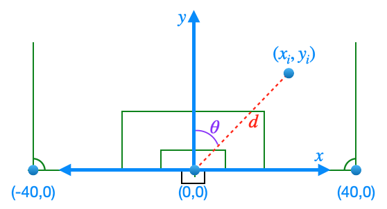

```r
#remove penalty & add dummy variables
wc_shots = wc_shots %>%
    filter(situation != 'penalty') %>%
    mutate(
        pos_d = ifelse(pos == 'D', 1, 0),
        pos_f = ifelse(pos == 'F', 1, 0),
        pos_m = ifelse(pos == 'M', 1, 0)
    )

# d & theta
wc_shots = wc_shots %>%
    mutate(
        d = sqrt(x^2 + y^2),
        theta = abs(atan2(x, y)) * (180/pi)
    )

wc_shots
```

```
# A tibble: 1,449 × 14
   shot_type situation body_part  shot_time player pos       x     y    xg pos_d
   <chr>     <chr>     <chr>          <dbl> <chr>  <chr> <dbl> <dbl> <dbl> <dbl>
 1 miss      assisted  left-foot       5693 Dejan… D       2.6  26.6 0.037     1
 2 miss      assisted  left-foot       5571 Nikol… F     -18    14.7 0.029     0
 3 save      assisted  left-foot       5303 Lovro… M       4.2  24.1 0.032     0
 4 miss      set-piece right-foot      4932 Alexi… M      -5    11.7 0.194     0
 5 miss      assisted  right-foot      4659 Misla… M      23    11.8 0.034     0
 6 miss      assisted  left-foot       4494 Ivan … M      21.7  31.9 0.012     0
 7 save      free-kick left-foot       4333 Ivan … M      -8.8  27.4 0.044     0
 8 goal      assisted  right-foot      4127 Juliá… F      -6.1   6.3 0.39      0
 9 block     set-piece head            3707 Dejan… D      -2     8.3 0.098     1
10 block     regular   right-foot      3455 Misla… M      19.9  20.9 0.023     0
# ℹ 1,439 more rows
# ℹ 4 more variables: pos_f <dbl>, pos_m <dbl>, d <dbl>, theta <dbl>
```